# S3.2) WK case study: Fully Bayesian analysis

This notebook contains the code of the paper "Bayesian Calibration of Imperfect Computer Models using Physics-Informed Priors". The models are fitted in rstan and the code is available in the folder "STAN/Windkessel".

#### Load libraries

Load libraries and functions to simulate data from the model

```r
# uncomment to install
# install.packages("rstan")
# install.packages("ggplot2")
# install.packages("ggpubr")
# install.packages("reshape2")
# install.packages("RColorBrewer")
library(rstan)
library(ggplot2)
library(ggpubr)
library(reshape2)
library(RColorBrewer)
theme_set(theme_classic()) # set ggplot theme
rstan_options(auto_write = TRUE)
options(mc.cores = 3) # allocate 3 cores (for each model we run 3 chains in parallel)
# numerical simulators of the WK2 and WK3 models
source("functions/WK2and3_sim_fn.R")
# functions to create observed data (noisy WK2 or WK3 data)
# and to extract the stan output
source("functions/WK_exp_fn.R")
# load inflow and time data
d = readRDS("Data/Inflow_time.rds")
```

#### Section 3.2: Fully Bayesian analysis with physics-informed priors

In this Section we simulate data from the Windkessel two parameters (WK2) differential equation and we fit the PI prior to the observed data.

$$\begin{equation}
Q(t) = \frac{1}{R}P(t) + C \frac{dP(t)}{dt}. \tag{WK2}
\end{equation}$$

Following Section 2.1, we built PI prior for the WK2 model as follows

$$\begin{equation}
\begin{split}
y_P & = P^{\text{WK2}}(t_P) + \varepsilon_P\\
y_Q & = Q^{\text{WK2}}(t_Q) + \varepsilon_Q,
\end{split}
\end{equation}$$
$\text{ where }P^{\text{WK2}}(t_P) \sim GP(\mu_P, K(t_P, t_P')), \varepsilon_P \sim N(0, \sigma^2_P) \text{ and } \varepsilon_Q \sim N(0,\sigma^2_Q).$ This results in the following multi-output GP prior
$$\begin{equation}
p(\mathbf{y}\mid \boldsymbol \theta, \boldsymbol \phi, \sigma_P, \sigma_Q) = \mathcal{N}(\boldsymbol{\mu}, \mathbf{K}),
\end{equation}$$

where $\bf{y} = \begin{bmatrix} \bf{y}_P \\ \bf{y}_Q \end{bmatrix},\boldsymbol{\mu} = \begin{bmatrix} \boldsymbol{\mu}_P \\ R^{-1}\boldsymbol{\mu}_P \end{bmatrix}$ and
$$\begin{split}\mathbf{K} =\begin{bmatrix}
K_{PP}(t_P, t_P \mid \boldsymbol \theta) + \sigma_P^2 I_P & K_{PQ}(t_P, t_Q \mid \boldsymbol \theta, \boldsymbol \phi)\\
K_{QP}(t_Q, t_P \mid \boldsymbol \theta, \boldsymbol \phi) & K_{QQ}(t_Q, t_Q \mid \boldsymbol \theta, \boldsymbol \phi) + \sigma_Q^2 I_Q
\end{bmatrix}.\end{split}$$

More specifically, for a given inflow (see below) we simulate three blood pressure cycles and we add to both $P(t)$ and $Q(t),$ i.i.d. Gaussian noise, $\varepsilon_P \sim N(0, 4^2)$ and $\varepsilon_Q \sim N(0,10^2).$ We also create replicates by synchronizing the three cycles in one (see Figure below).

```r
# true parameter values (Ztrue=0 corresponds to the WK2 model)
Rtrue = 1; Ctrue = 1.1; Ztrue = 0.0
flow = d$inflow*0.95 # obserevd inflow
time = d$time # corresponding observed time
# For the observed flow and the corresponding observed time
# simulate pressure data from the WK2 model
# for the given Rtrue and Ctrue values
# return 3 cycles (nc=3) of pressure and flow
# with 20 pressure points at each cycle (nP=20)
# and 17 pressure points at each cycle (nI=17)
# for both pressure and inflow add N(0,4^2) and N(0, 10^2) i.i.d. noise
# Create also predictions on a grid of 50 time points (n_pred=50)
ddd = create_data(flow, time, Rtrue, Ctrue, Ztrue=Ztrue,
                  nc=3, nP=20, nI=17, n_pred=50, Pnoise=4, Inoise=10, seed = 0)
```

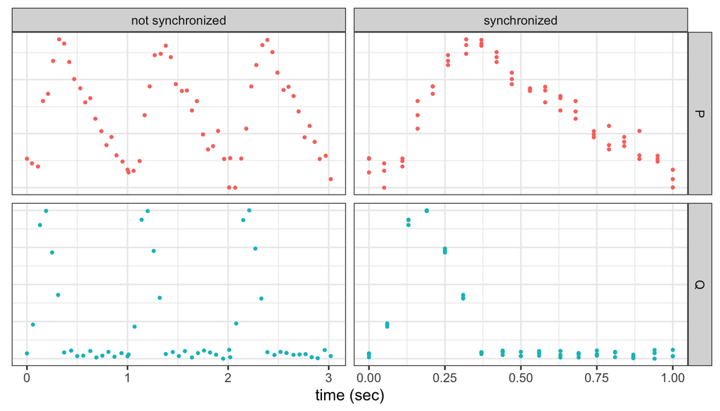

### Squared exponential (SE) kernel model

We fit the model using the squared expinential kernel as a prior choice, $K_{PP}(t,t') = \sigma^2{ exp\left(- 0.5\,{ \left( {\frac {t-t'}{l}} \right) }^{2}\right)}.$

Stan code (select `eval=TRUE` in the code chunk to see the stan code):

```r
writeLines(readLines('STAN/Windkessel/SE/WK2__SE_PI_prior.stan'))
```

```r
fit_sq_exp = stan(file='STAN/Windkessel/SE/WK2__SE_PI_prior.stan',
                  data=ddd$data_noisy_pred,
                  chains=3,
                  iter=1000,
                  seed=123
)
```

Trace plots

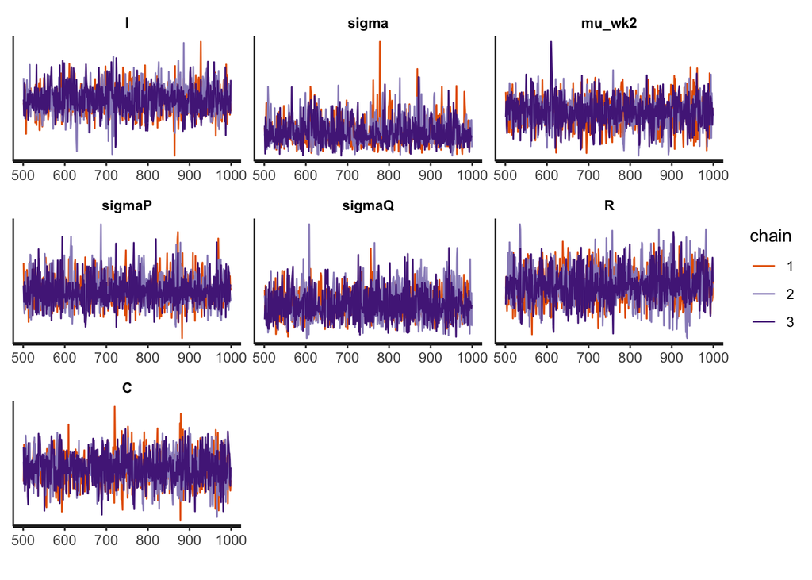

```r
stan_trace(fit_sq_exp, pars=names(fit_sq_exp)[1:7])+
  theme(axis.title.y=element_blank(),
        axis.text.y=element_blank(),
        axis.ticks.y=element_blank())
```

Transforming the posterior in the original scale

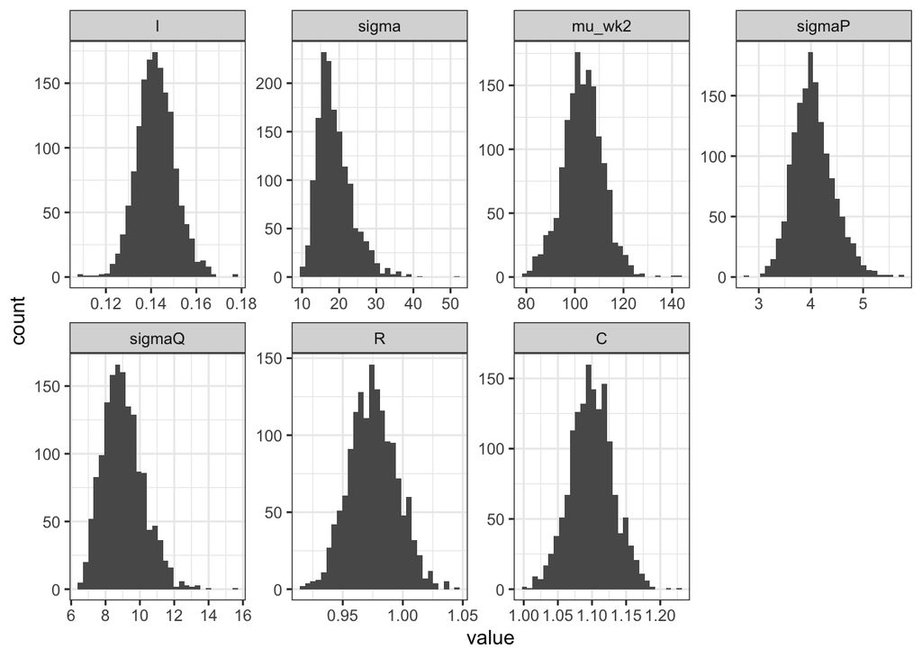

```r
y = ddd$y # the original observed data
pp_se= transform_post(y, fit_sq_exp)
pl_df=pp_se[,names(fit_sq_exp)[1:7]]
pl_df$sample=1:nrow(pl_df)
m_pl_df = melt(pl_df, id="sample")
ggplot(data=m_pl_df)+
  geom_histogram(aes(x=value))+
  facet_wrap(~variable,nrow = 2, scales = "free")+theme_bw()
```

### Rational quadratic (RQ) kernel model

Now we fit the model using the rational quadratic kernel as a prior choice, $K_{\textrm{PP}}(t, t') = \sigma^2 \left( 1 + \frac{(t - t')^2}{2 \alpha \ell^2} \right)^{-\alpha}.$

Stan code (select `eval=TRUE` in the code chunk to see the stan code):

```r
writeLines(readLines('STAN/Windkessel/RQ/WK2__RQ_PI_prior.stan'))
```

```r
fit_rat_quad = stan(file  = 'STAN/Windkessel/RQ/WK2__RQ_PI_prior.stan',
                    data = ddd$data_noisy_pred,
                    chains = 3,
                    iter = 1000,
                    seed = 0
)
```

Trace plots

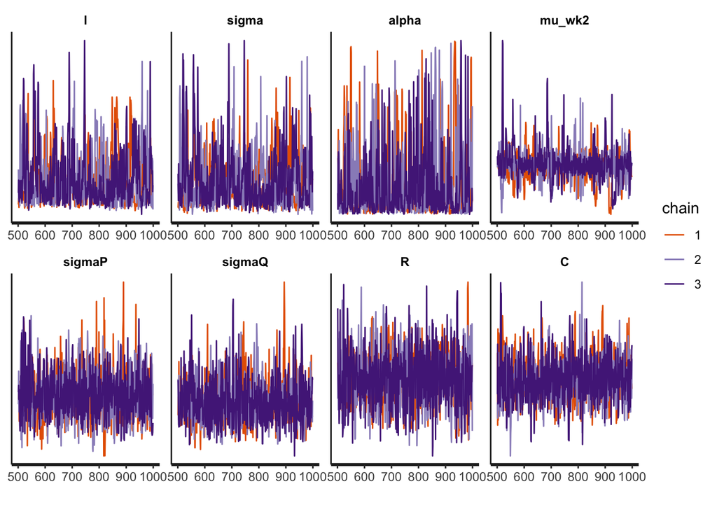

```r
stan_trace(fit_rat_quad, pars=names(fit_rat_quad)[1:8], nrow = 2)+
  theme(axis.title.y=element_blank(),
        axis.text.y=element_blank(),
        axis.ticks.y=element_blank())
```

Transforming the posterior in the original scale

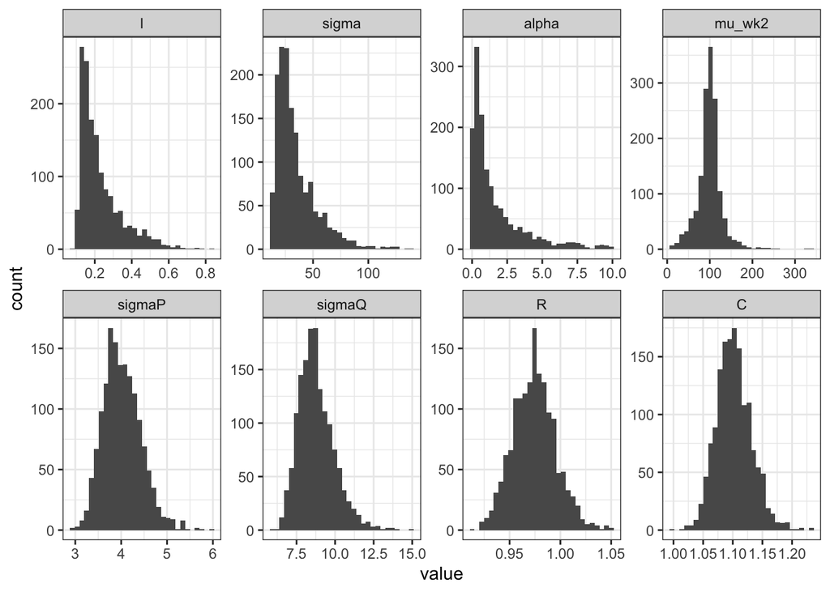

```r
y = ddd$y
pp_rq = transform_post(y=y, fit=fit_rat_quad)
pl_df=pp_rq[,names(fit_rat_quad)[1:8]]
pl_df$sample=1:nrow(pl_df)
m_pl_df = melt(pl_df, id="sample")
ggplot(data=m_pl_df)+
  geom_histogram(aes(x=value))+
  facet_wrap(~variable,nrow = 2, scales = "free")+theme_bw()
```

### Periodic (Per) kernel model

We fit the model using the periodic kernel as a prior choice, $K_{\textrm{Per}}(t,t') = \sigma^2\exp\left(-\frac{2\sin^2(\pi(t - t')p)}{\ell^2}\right).$ and we use the "raw" data (not synchronized in one cycle).

Stan code (select `eval=TRUE` in the code chunk to see the stan code):

```r
writeLines(readLines('STAN/Windkessel/Per/WK2__Per_PI_prior.stan'))
```

Fit model

```r
fit_per = stan(file  = 'STAN/Windkessel/Per/WK2__Per_PI_prior.stan',
               data = data_withPred,
               chains = 3,
               iter = 1000,
               seed = 123
)
```

Trace plots

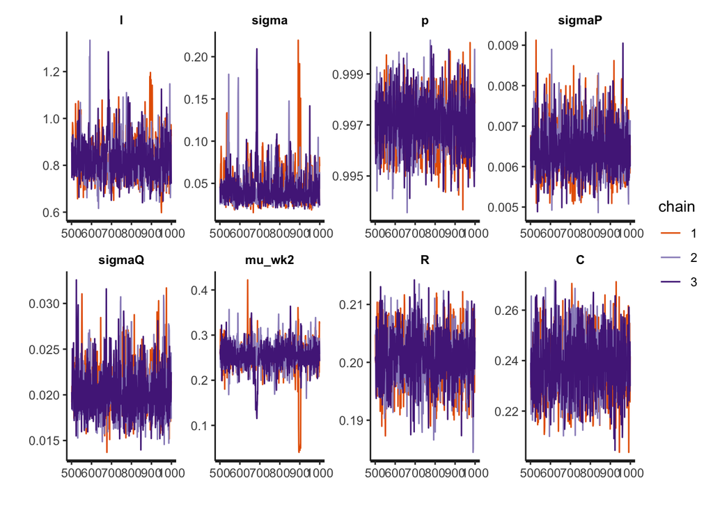

```r
stan_trace(fit_per, pars=names(fit_per)[1:8], nrow = 2)
```

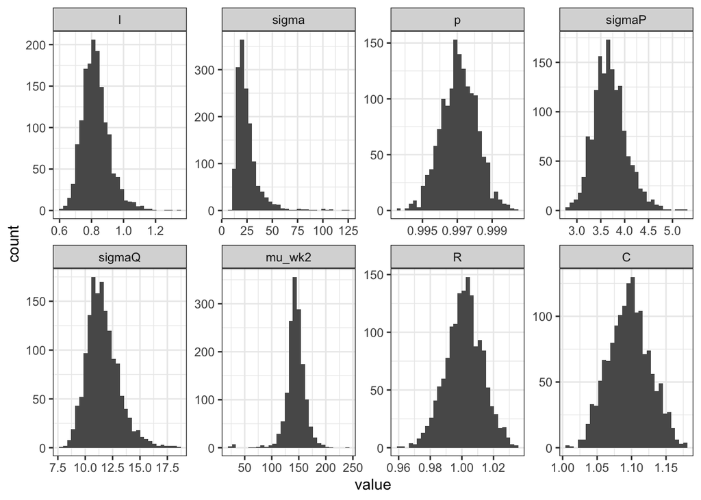

```r
pp_pe = transform_post(y=y, fit=fit_per)
pl_df=pp_pe[,names(fit_per)[1:8]]
pl_df$sample=1:nrow(pl_df)
m_pl_df = melt(pl_df, id="sample")
ggplot(data=m_pl_df)+
  geom_histogram(aes(x=value))+
  facet_wrap(~variable,nrow = 2, scales = "free")+theme_bw()
```

### Plots in Section 3.2

The posterior distributions and the predictions of Section 3.2 are presented.

#### Posterior distributions of $R,C,\sigma_P \text{ and } \sigma_Q$

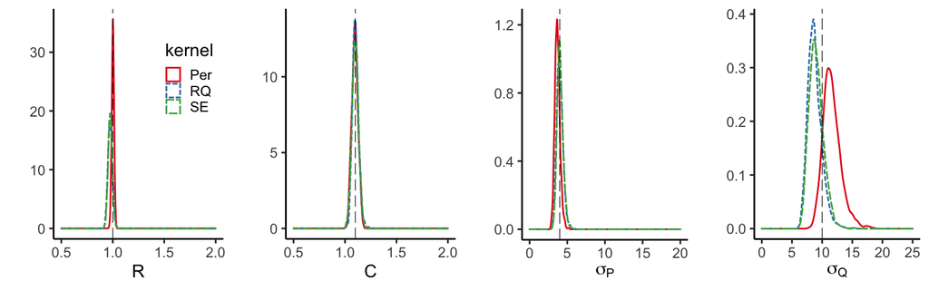

```r
rd = list(
  data_list_SE_RQ = ddd$data_noisy_pred, data_list_Per = data_withPred
  , pp_se=pp_se, pp_rq=pp_rq, pp_pe=pp_pe
  , obsP_SE_RQ=data.frame(obs = ddd$y[1:ddd$data_noisy_pred$nP],
                          time = ddd$data_noisy_pred$tP)
  , obsP_Per=data.frame(obs=yP, time=tP)
  , obsI_SE_RQ=data.frame(obs = ddd$y[(ddd$data_noisy_pred$nP+1):length(ddd$y)],
                          time = ddd$data_noisy_pred$tI)
  , obsI_Per=data.frame(obs=yI, time=tI)
  , data_mod_true_SE_RQ = ddd$data_mod_true
  , data_mod_true_Per = data.frame(P=Pobs, I=flow, time=time)
  )
cols_kernel = brewer.pal(3, "Set1")
Rtrue=1; Ctrue=1.1
attach(rd)
nsample = nrow(pp_se)
post = data.frame(kernel = c(rep("SE",nsample), rep("RQ", nsample), rep("Per", nsample)))

post$R = c(pp_se$R, pp_rq$R, pp_pe$R)
post$C = c(pp_se$C, pp_rq$C, pp_pe$C)
post$sigmaP = c(pp_se$sigmaP, pp_rq$sigmaP, pp_pe$sigmaP)
post$sigmaQ = c(pp_se$sigmaQ, pp_rq$sigmaQ, pp_pe$sigmaQ)

plR = ggplot()+
  geom_density(data = post, aes(x=R, color=kernel, linetype=kernel))+
  geom_vline(xintercept = Rtrue, linetype = "longdash",size=0.2)+
  xlim(0.5,2)+ ylab("")+
  theme(legend.position = c(0.8,0.7)
        ,legend.key.size = unit(0.35, 'cm')
  ) + scale_color_brewer(palette="Set1")
plC =ggplot()+
  geom_density(data = post, aes(x=C, color=kernel, linetype=kernel))+
  geom_vline(xintercept = Ctrue, linetype = "longdash",size=0.2)+
  xlim(0.5,2)+ylab("")+ theme(legend.position = "none") +
  scale_color_brewer(palette="Set1")

plPsig =ggplot()+
  geom_density(data = post, aes(x=sigmaP, color=kernel, linetype=kernel))+
  geom_vline(xintercept = 4, linetype = "longdash",size=0.2)+
  xlim(0,20)+ylab("")+xlab(expression(sigma[P]))+
  theme(legend.position = "none") + scale_color_brewer(palette="Set1")

plQsig =ggplot()+
  geom_density(data = post, aes(x=sigmaQ, color=kernel, linetype=kernel))+
  geom_vline(xintercept = 10, linetype = "longdash",size=0.2)+
  xlim(0,25)+ylab("")+xlab(expression(sigma[Q]))+
  theme(legend.position = "none") + scale_color_brewer(palette="Set1")


(pl_kernels = ggarrange(plR, plC, plPsig, plQsig,nrow = 1))
```

#### Blood pressure, P(t) and inflow, Q(t) predictions

The predictions can be obtained using the prediction equations in Sections 2.1 and 2.2.

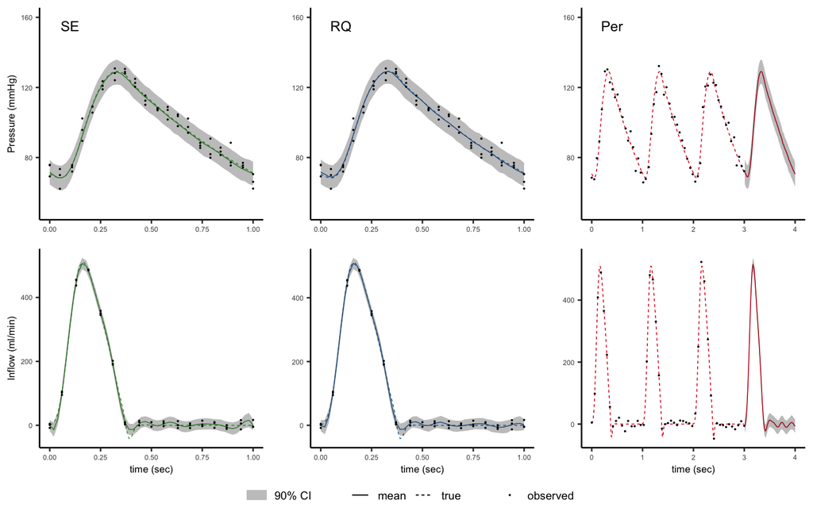

```r
t.size = 5
l.size = 7
size.line = 0.3

### Pressure predictions
cn = colnames(pp_se)
yP_SE = pp_se[,grep("y_P", cn)]
P_mean_CIs = data.frame(
  mean = colMeans(yP_SE)
  , lower = apply(yP_SE,2,quantile,probs=0.05)
  , upper = apply(yP_SE,2,quantile,probs=0.95)
)
P_mean_CIs$time = data_list_SE_RQ$tP_pred

pl_Ppred_SE = ggplot(P_mean_CIs) +
  geom_line(aes(y=mean, x=time, linetype = "mean"),
            colour = cols_kernel[3], size=size.line)+
  geom_line(data=data_mod_true_SE_RQ, aes(y=P, x=time, linetype = "true"),
            colour = cols_kernel[3], size=size.line)+
  geom_ribbon(aes(ymin=lower, ymax=upper, x=time, fill = "95% CI"), alpha = 0.3)+
  geom_point(data= obsP_SE_RQ, aes(x=time, y=obs, shape = "observed"), size=0.4)+
  scale_fill_manual("",values=c("95% CI" = "grey12"))+
  theme(#legend.position = c(0.8, 0.8)
    legend.position = "none"
    , legend.title = element_blank()
    , axis.title.x = element_blank()
    , legend.spacing.y = unit(0.01, 'cm')
    , legend.direction = "horizontal"
    , legend.background = element_rect(fill='transparent')
    , legend.key.size = unit(0.3, 'cm')
    , legend.key.height = unit(0.05, 'cm')
    , legend.spacing.x = unit(0.01, 'cm')
    , axis.text = element_text(size = t.size)
    , axis.title = element_text(size = l.size)
  )+
  ylab("Pressure (mmHg)") +
  guides(colour = guide_legend(nrow = 1))+
  ylim(50,160) +
  annotate('text', x = 0.1, y = 155, fontface =2,label = "SE",parse = TRUE,size=3.5)

cn = colnames(pp_rq)
yP_RQ = pp_rq[,grep("y_P", cn)]
P_mean_CIs = data.frame(
  mean = colMeans(yP_RQ)
  , lower = apply(yP_RQ,2,quantile,probs=0.05)
  , upper = apply(yP_RQ,2,quantile,probs=0.95)
)
P_mean_CIs$time = data_list_SE_RQ$tP_pred

pl_Ppred_RQ = ggplot(P_mean_CIs) +
  geom_line(aes(y=mean, x=time, linetype = "mean"),
            colour = cols_kernel[2], size=size.line)+
  geom_line(data=data_mod_true_SE_RQ, aes(y=P, x=time, linetype = "true"),
            colour = cols_kernel[2], size=size.line)+
  geom_ribbon(aes(ymin=lower, ymax=upper, x=time, fill = "95% CI"), alpha = 0.3)+
  geom_point(data= obsP_SE_RQ, aes(x=time, y=obs, shape = "observed"), size=0.4)+
  scale_fill_manual("",values=c("95% CI" = "grey12"))+
  theme(#legend.position = c(0.8, 0.8)
    legend.position = "none"
    , legend.title = element_blank()
    , axis.title.x = element_blank()
    , legend.spacing.y = unit(0.01, 'cm')
    , legend.direction = "horizontal"
    , legend.background = element_rect(fill='transparent')
    , legend.key.size = unit(0.3, 'cm')
    , legend.key.height = unit(0.05, 'cm')
    , legend.spacing.x = unit(0.01, 'cm')
    , axis.text = element_text(size = t.size)
    , axis.title = element_text(size = l.size)
  )+
  ylab("") +
  guides(colour = guide_legend(nrow = 1))+
  ylim(50,160) +
  annotate('text', x = 0.1, y = 155, fontface =2,label = "RQ",parse = TRUE,size=3.5)

cn = colnames(pp_pe)
yP_Per = pp_rq[,grep("y_P", cn)]
P_mean_CIs = data.frame(
  mean = colMeans(yP_Per)
  , lower = apply(yP_Per,2,quantile,probs=0.05)
  , upper = apply(yP_Per,2,quantile,probs=0.95)
)
P_mean_CIs$time = data_list_Per$tP_pred

pl_Ppred_Per = ggplot(P_mean_CIs) +
  geom_line(aes(y=mean, x=time, linetype = "mean"),
            colour = cols_kernel[1], size=size.line)+
  geom_line(data=data_mod_true_Per, aes(y=P, x=time, linetype = "true"),
            colour = cols_kernel[1], size=size.line)+
  geom_ribbon(aes(ymin=lower, ymax=upper, x=time, fill = "95% CI"), alpha = 0.3)+
  geom_point(data= obsP_Per, aes(x=time, y=obs, shape = "observed"), size=0.4)+
  scale_fill_manual("",values=c("95% CI" = "grey12"))+
  theme(#legend.position = c(0.8, 0.8)
    legend.position = "none"
    , legend.title = element_blank()
    , axis.title.x = element_blank()
    , legend.spacing.y = unit(0.01, 'cm')
    , legend.direction = "horizontal"
    , legend.background = element_rect(fill='transparent')
    , legend.key.size = unit(0.3, 'cm')
    , legend.key.height = unit(0.05, 'cm')
    , legend.spacing.x = unit(0.01, 'cm')
    , axis.text = element_text(size = t.size)
    , axis.title = element_text(size = l.size)
  )+
  ylab("") +
  guides(colour = guide_legend(nrow = 1))+
  ylim(50,160) +
  annotate('text', x = 0.4, y = 155, fontface =2,label = "Per",parse = TRUE,size=3.5)
pl_Ppred_kernels = ggarrange(pl_Ppred_SE, pl_Ppred_RQ, pl_Ppred_Per, nrow = 1)
#---------------------------------------

### Inflow predictions
cn = colnames(pp_se)
yI_SE = pp_se[,grep("y_I", cn)]
I_mean_CIs = data.frame(
  mean = colMeans(yI_SE)
  , lower = apply(yI_SE,2,quantile,probs=0.05)
  , upper = apply(yI_SE,2,quantile,probs=0.95)
)
I_mean_CIs$time = data_list_SE_RQ$tI_pred

pl_Ipred_SE = ggplot(I_mean_CIs) +
  geom_line(aes(y=mean, x=time, linetype = "mean"), colour = cols_kernel[3], size=size.line)+
  geom_line(data=data_mod_true_SE_RQ, aes(y=I, x=time, linetype = "true"), colour = cols_kernel[3], size=size.line)+
  geom_ribbon(aes(ymin=lower, ymax=upper, x=time, fill = "90% CI"), alpha = 0.3)+
  geom_point(data= obsI_SE_RQ, aes(x=time, y=obs, shape = "observed"), size=0.4)+
  scale_fill_manual("",values=c("90% CI" = "grey12"))+
  theme(legend.position = "none"
        , legend.title = element_blank()
        #, axis.title.x = element_blank()
        , legend.direction = "horizontal"
        , legend.background = element_rect(fill='transparent')
        , legend.key.size = unit(0.3, 'cm')
        , legend.key.height = unit(0.01, 'cm')
        , legend.text = element_text(size=6)
        , legend.spacing.y  = unit(0.01, 'cm')
        , axis.text = element_text(size = t.size)
        , axis.title = element_text(size = l.size)
  )+
  xlab("time (sec)")+ylab("Inflow (ml/min)")

cn = colnames(pp_rq)
yI_RQ = pp_rq[,grep("y_I", cn)]
I_mean_CIs = data.frame(
  mean = colMeans(yI_RQ)
  , lower = apply(yI_RQ,2,quantile,probs=0.05)
  , upper = apply(yI_RQ,2,quantile,probs=0.95)
)
I_mean_CIs$time = data_list_SE_RQ$tI_pred

pl_Ipred_RQ = ggplot(I_mean_CIs) +
  geom_line(aes(y=mean, x=time, linetype = "mean"),
            colour = cols_kernel[2], size=size.line)+
  geom_line(data=data_mod_true_SE_RQ, aes(y=I, x=time, linetype = "true"),
            colour = cols_kernel[2], size=size.line)+
  geom_ribbon(aes(ymin=lower, ymax=upper, x=time, fill = "90% CI"), alpha = 0.3)+
  geom_point(data= obsI_SE_RQ, aes(x=time, y=obs, shape = "observed"), size=0.4)+
  scale_fill_manual("",values=c("90% CI" = "grey12"))+
  theme(legend.position = "none"
        , legend.title = element_blank()
        , legend.direction = "horizontal"
        , legend.background = element_rect(fill='transparent')
        , legend.key.size = unit(0.3, 'cm')
        , legend.key.height = unit(0.01, 'cm')
        , legend.text = element_text(size=6)
        , legend.spacing.y  = unit(0.01, 'cm')
        , axis.text = element_text(size = t.size)
        , axis.title = element_text(size = l.size)
  )+
 xlab("time (sec)")+ylab("")

cn = colnames(pp_pe)
yI_Per = pp_pe[,grep("y_I", cn)]
I_mean_CIs = data.frame(
  mean = colMeans(yI_Per)
  , lower = apply(yI_Per,2,quantile,probs=0.05)
  , upper = apply(yI_Per,2,quantile,probs=0.95)
)
I_mean_CIs$time = data_list_Per$tI_pred

pl_Ipred_Per = ggplot(I_mean_CIs) +
  geom_line(aes(y=mean, x=time, linetype = "mean"),
            colour = cols_kernel[1], size=size.line)+
  geom_line(data=data_mod_true_Per, aes(y=I, x=time, linetype = "true"),
            colour = cols_kernel[1], size=size.line)+
  geom_ribbon(aes(ymin=lower, ymax=upper, x=time, fill = "90% CI"), alpha = 0.3)+
  geom_point(data= obsI_Per, aes(x=time, y=obs, shape = "observed"), size=0.4)+
  scale_fill_manual("",values=c("90% CI" = "grey12"))+
  theme(legend.position = "none"
        , legend.title = element_blank()
        , legend.direction = "horizontal"
        , legend.background = element_rect(fill='transparent')
        , legend.key.size = unit(0.3, 'cm')
        , legend.key.height = unit(0.01, 'cm')
        , legend.text = element_text(size=6)
        , legend.spacing.y  = unit(0.01, 'cm')
        , axis.text = element_text(size = t.size)
        , axis.title = element_text(size = l.size)
  )+
  xlab("time (sec)")+ylab("")
pl_Ipred_kernels = ggarrange(pl_Ipred_SE, pl_Ipred_RQ, pl_Ipred_Per, nrow = 1)
### create unique legend for all
pl_pred_legend = ggplot(I_mean_CIs) +
  geom_line(aes(y=mean, x=time, linetype = "mean"),
            colour = "black", size=size.line)+
  geom_line(data=data_mod_true_Per, aes(y=I, x=time, linetype = "true"),
            colour = "black", size=size.line)+
  geom_ribbon(aes(ymin=lower, ymax=upper, x=time, fill = "90% CI"), alpha = 0.3)+
  geom_point(data= obsI_Per, aes(x=time, y=obs, shape = "observed"), size=0.4)+
  scale_fill_manual("",values=c("90% CI" = "grey12"))+
  theme(legend.position = c(0.7, 0.7)
        , legend.title = element_blank()
        , axis.title.x = element_blank()
        , legend.direction = "horizontal"
        , legend.background = element_rect(fill='transparent')
        , legend.key.size = unit(0.5, 'cm')
        , legend.key.height = unit(0.01, 'cm')
        , legend.text = element_text(size=8)
        , legend.spacing.y  = unit(0.01, 'cm')
        , axis.text = element_text(size = t.size)
        , axis.title = element_text(size = l.size)
  )+
  ylab("")
pl_PIpred = ggarrange(pl_Ppred_kernels, pl_Ipred_kernels, nrow = 2
                      , legend = "bottom", common.legend = TRUE
                      , legend.grob =
                        get_legend(pl_pred_legend, position = "bottom"))
pl_PIpred
```

The total run time is

```
Time difference of 9.038925 mins
```